# reg pls

M.NEKUI TIEFANG BIEDIANT

2023-03-29

PLS = partial least squares // moindre carré partiel

```
              jargon
```

*construit: var latente (non observable) ex: la famine*  
modèle de mesure: lien entre var observé et leur var latente ex: avez vous fin ? et combien de fois avez vous mangé ? *modèle de structure: relation entre une var latente et d’autre var latente ex: la famine qui viendra predire le bonheur* modele formatif vs reflectif *CB-SEM: covariance-based structural equation (eqution structurelle basé sur la covariance)* CB-PLS

```
        Conditions d'application
```

les donneés ne respectent pas les hypothèses sous-jacentes aux equations structurelles: *données non quanti quanti, resid pas normalisé, données de petite taille*

```r
library(seminr)
data=read.csv("/home/nekui-tiefang/Documents/mes codes R/reg pls/rintro-chapter10sat.csv")
summary(data)
```

```
##        q1             q2              q3              c1             c2
##  Min.   :1.00   Min.   :1.000   Min.   :1.000   Min.   :1.00   Min.   :1.000
##  1st Qu.:3.00   1st Qu.:3.000   1st Qu.:3.000   1st Qu.:3.00   1st Qu.:3.000
##  Median :4.00   Median :3.000   Median :4.000   Median :4.00   Median :4.000
##  Mean   :3.95   Mean   :3.535   Mean   :3.805   Mean   :4.34   Mean   :4.185
##  3rd Qu.:5.00   3rd Qu.:4.000   3rd Qu.:4.000   3rd Qu.:5.00   3rd Qu.:5.000
##  Max.   :7.00   Max.   :7.000   Max.   :7.000   Max.   :7.00   Max.   :7.000
##        c3              v1              v2             v3             cs1
##  Min.   :1.000   Min.   :1.000   Min.   :1.00   Min.   :1.000   Min.   :1.000
##  1st Qu.:4.000   1st Qu.:4.000   1st Qu.:3.00   1st Qu.:4.000   1st Qu.:3.000
##  Median :4.000   Median :5.000   Median :4.00   Median :5.000   Median :4.000
##  Mean   :4.395   Mean   :4.565   Mean   :3.87   Mean   :4.595   Mean   :3.715
##  3rd Qu.:5.000   3rd Qu.:5.000   3rd Qu.:5.00   3rd Qu.:5.000   3rd Qu.:5.000
##  Max.   :7.000   Max.   :7.000   Max.   :7.00   Max.   :7.000   Max.   :7.000
##       cs2             cs3             r1             r2              r3
##  Min.   :1.000   Min.   :1.00   Min.   :1.00   Min.   :1.000   Min.   :1.000
##  1st Qu.:2.000   1st Qu.:3.00   1st Qu.:3.00   1st Qu.:3.000   1st Qu.:3.000
##  Median :3.000   Median :4.00   Median :4.00   Median :4.000   Median :4.000
##  Mean   :3.255   Mean   :3.59   Mean   :3.92   Mean   :3.895   Mean   :3.695
##  3rd Qu.:4.000   3rd Qu.:4.25   3rd Qu.:5.00   3rd Qu.:5.000   3rd Qu.:5.000
##  Max.   :7.000   Max.   :7.00   Max.   :7.00   Max.   :7.000   Max.   :7.000
```

description de la bd

C: coût Q: qualite CS: client satisfait R: repeat V:value

qui sont bien evidament les variables latente

TAF: ici on doit prédire la repetion de l’achat d’un consommateur sur la base du coût de la satisfaction de ce client, de la valeur qu’il persoit et la qualité du produit

```
              PLS-SEM
```

modele de mesure

```r
mm= constructs(
  composite("Quality",multi_items("q", 1:3)),
  composite("Value",multi_items("v", 1:3)),
  composite("Cost",multi_items("c", 1:3)),
  composite("Csat",multi_items("cs", 1:3)),
  composite("Repeat",multi_items("r", 1:3))
                )
```

modele de structure

```r
ms=relationships(
  paths("Cost",c("Value","Repeat")),
  paths("Quality",c("Value","Csat")),
  paths("Value","Csat"),
  paths("Csat","Repeat")
)
```

semir terminé

```
  estimation du modèle
```

```r
modelPLS=estimate_pls(data,mm,ms)
```

```
## Generating the seminr model
```

```
## All 200 observations are valid.
```

```r
sum=summary(modelPLS)
sum
```

```
##
## Results from  package seminr (2.3.2)
##
## Path Coefficients:
##          Value Repeat  Csat
## R^2      0.174  0.212 0.210
## AdjR^2   0.165  0.204 0.202
## Cost    -0.270 -0.317     .
## Quality  0.297      . 0.342
## Value        .      . 0.215
## Csat         .  0.289     .
##
## Reliability:
##         alpha  rhoC   AVE  rhoA
## Cost    0.737 0.851 0.655 0.744
## Quality 0.685 0.826 0.612 0.695
## Value   0.773 0.868 0.686 0.779
## Csat    0.725 0.844 0.644 0.729
## Repeat  0.695 0.827 0.614 0.720
##
## Alpha, rhoC, and rhoA should exceed 0.7 while AVE should exceed 0.5
```

```r
plot(modelPLS)
```

[interactive chart not shown]

nous voyons la representation graphique d’un model pls entre chaque var observé et sa var latent, il doit y avoir au minimun un lien sup 0.708 pourqu’il soit significatif et s’il est en dessuq de 0.4 il vas falloir le supprimer

nous vayons aussi le r square qui est le pourcentage explique par le modelpls

```
              testons le bootstrap de model notre
```

calcul de l’échantillon avec remise a partir de l’echantillon gobal

```r
btpls=bootstrap_model(modelPLS, rboot=1000)
```

```
## Bootstrapping model using seminr...
```

```
## SEMinR Model successfully bootstrapped
```

```r
sumboot=summary(btpls, alpha=0.05)
```

representation du modèle complet avec IC et significativité

```r
plot(btpls)
```

[interactive chart not shown]

assessment: modele de mesure

```r
sum$loadings**2 #fiabilité de l'indicateur
```

```
##      Cost Quality Value  Csat Repeat
## q1  0.000   0.571 0.000 0.000  0.000
## q2  0.000   0.592 0.000 0.000  0.000
## q3  0.000   0.673 0.000 0.000  0.000
## v1  0.000   0.000 0.672 0.000  0.000
## v2  0.000   0.000 0.676 0.000  0.000
## v3  0.000   0.000 0.709 0.000  0.000
## c1  0.620   0.000 0.000 0.000  0.000
## c2  0.709   0.000 0.000 0.000  0.000
## c3  0.636   0.000 0.000 0.000  0.000
## cs1 0.000   0.000 0.000 0.640  0.000
## cs2 0.000   0.000 0.000 0.632  0.000
## cs3 0.000   0.000 0.000 0.660  0.000
## r1  0.000   0.000 0.000 0.000  0.589
## r2  0.000   0.000 0.000 0.000  0.694
## r3  0.000   0.000 0.000 0.000  0.560
```

```r
sum$reliability #fiabilité interne
```

```
##         alpha  rhoC   AVE  rhoA
## Cost    0.737 0.851 0.655 0.744
## Quality 0.685 0.826 0.612 0.695
## Value   0.773 0.868 0.686 0.779
## Csat    0.725 0.844 0.644 0.729
## Repeat  0.695 0.827 0.614 0.720
##
## Alpha, rhoC, and rhoA should exceed 0.7 while AVE should exceed 0.5
```

```r
sum$validity$fl_criteria #validité discriminante
```

```
##           Cost Quality Value  Csat Repeat
## Cost     0.809       .     .     .      .
## Quality -0.077   0.782     .     .      .
## Value   -0.293   0.318 0.828     .      .
## Csat    -0.153   0.410 0.324 0.803      .
## Repeat  -0.361   0.171 0.162 0.337  0.784
##
## FL Criteria table reports square root of AVE on the diagonal and construct correlations on the lower triangle.
```

le sum$loadings**2 (nous elevons au carré pour nous epargner des valeurs négative) est utilisé pour savoir en pourcentage si le construit explique la variance de ces valeurs observable et il est significatif si sa valeur est au minimun de 40%( soit 63% dans la realité) lorsqu’il n’atteind pas cette valeur il faudre songer a le supprimer Dans notre exemple, nos pourcentage de significativité est acceptable

pour la commande sum$reliability qui conserne la fiabilité interne comme le resultat l’indique Alpha, rhoC, rhoA doit être sup a 0.7 tandis que AVE (variance moyenne extraite) quant ta lui toute les variable doivent exceder 0.5 sur sa colonne

pour la commande sum$validity$fl_critera (validité discriminante) il est question de verifier si chaque construit est differnt d’un autre construit ici la condition de validité est que les valeurs de la première bissectrice doit etre sup a toute les autre valeur de la colonne

```
    assessment: modele de structure
```

```r
sum$vif_antecedents # probème de colinearité (pas sup a 5 )
```

```
## Value :
##    Cost Quality
##   1.006   1.006
##
## Repeat :
##  Cost  Csat
## 1.024 1.024
##
## Csat :
## Quality   Value
##   1.112   1.112
```

```r
sumboot$bootstrapped_paths #qualité des relations (pas de 0 dans IC)
```

```
##                    Original Est. Bootstrap Mean Bootstrap SD T Stat. 2.5% CI
## Cost  ->  Value           -0.270         -0.276        0.070  -3.853  -0.408
## Cost  ->  Repeat          -0.317         -0.322        0.057  -5.584  -0.425
## Quality  ->  Value         0.297          0.296        0.072   4.105   0.154
## Quality  ->  Csat          0.342          0.349        0.060   5.672   0.232
## Value  ->  Csat            0.215          0.214        0.074   2.920   0.065
## Csat  ->  Repeat           0.289          0.292        0.060   4.838   0.169
##                    97.5% CI
## Cost  ->  Value      -0.135
## Cost  ->  Repeat     -0.213
## Quality  ->  Value    0.430
## Quality  ->  Csat     0.463
## Value  ->  Csat       0.356
## Csat  ->  Repeat      0.402
```

```r
sumboot$bootstrapped_total_paths #qualité plus détaillé des relations (pas de 0 dans IC)
```

```
##                     Original Est. Bootstrap Mean Bootstrap SD T Stat. 2.5% CI
## Cost  ->  Value            -0.270         -0.276        0.070  -3.853  -0.408
## Cost  ->  Csat             -0.058         -0.059        0.026  -2.230  -0.116
## Cost  ->  Repeat           -0.334         -0.339        0.057  -5.908  -0.440
## Quality  ->  Value          0.297          0.296        0.072   4.105   0.154
## Quality  ->  Csat           0.406          0.413        0.054   7.551   0.302
## Quality  ->  Repeat         0.117          0.121        0.029   4.095   0.064
## Value  ->  Csat             0.215          0.214        0.074   2.920   0.065
## Value  ->  Repeat           0.062          0.062        0.023   2.702   0.021
## Csat  ->  Repeat            0.289          0.292        0.060   4.838   0.169
##                     97.5% CI
## Cost  ->  Value       -0.135
## Cost  ->  Csat        -0.014
## Cost  ->  Repeat      -0.235
## Quality  ->  Value     0.430
## Quality  ->  Csat      0.510
## Quality  ->  Repeat    0.178
## Value  ->  Csat        0.356
## Value  ->  Repeat      0.111
## Csat  ->  Repeat       0.402
```

```r
sum$paths # R-carré
```

```
##          Value Repeat  Csat
## R^2      0.174  0.212 0.210
## AdjR^2   0.165  0.204 0.202
## Cost    -0.270 -0.317     .
## Quality  0.297      . 0.342
## Value        .      . 0.215
## Csat         .  0.289     .
```

le problème de colinearité est resolu les qualités des relations sont bonnes (pas de zero dans IC) par contre le R**2 carré est assez faible !!!

```
            MEDIATIONS
```

**inspection des effets indirects sur le bootstrap du model

```r
specific_effect_significance(btpls,from = "Quality",through = "Value", to="Csat")
```

```
##  Original Est. Bootstrap Mean   Bootstrap SD        T Stat.        2.5% CI
##     0.06377068     0.06362046     0.02746821     2.32161776     0.01690380
##       97.5% CI
##     0.12070363
```

```r
specific_effect_significance(btpls, from = "Cost",through = c("Value","Csat"),to="Repeat")
```

```
##  Original Est. Bootstrap Mean   Bootstrap SD        T Stat.        2.5% CI
##   -0.016774775   -0.017166867    0.008171990   -2.052716009   -0.034133932
##       97.5% CI
##   -0.004094391
```

*la premiere commande nous montre bien que le coefficient entre quality et csat est significatif (pas de 0 dans IC) ont conclu alors que quality influence csat a travers la mediatrice value* pour la seconde scommande nous pouvons aussi dire que le cost influence directement et indirectement (mediations value et csat) repeat avec significacité dans les deux cas

**inspection des effets direct

```r
sumboot$bootstrapped_paths
```

```
##                    Original Est. Bootstrap Mean Bootstrap SD T Stat. 2.5% CI
## Cost  ->  Value           -0.270         -0.276        0.070  -3.853  -0.408
## Cost  ->  Repeat          -0.317         -0.322        0.057  -5.584  -0.425
## Quality  ->  Value         0.297          0.296        0.072   4.105   0.154
## Quality  ->  Csat          0.342          0.349        0.060   5.672   0.232
## Value  ->  Csat            0.215          0.214        0.074   2.920   0.065
## Csat  ->  Repeat           0.289          0.292        0.060   4.838   0.169
##                    97.5% CI
## Cost  ->  Value      -0.135
## Cost  ->  Repeat     -0.213
## Quality  ->  Value    0.430
## Quality  ->  Csat     0.463
## Value  ->  Csat       0.356
## Csat  ->  Repeat      0.402
```

conclusion les deux relation de mediation sont *complementaire* des relation directe dans notre model du fait du même signe des *Original Est* et IC

```
          valeur predicte du modele
```

verifions si notre modèle est bon au dela de l’echantillon

```r
predicpls=predict_pls(model = modelPLS, technique = predict_DA, noFolds = 10, reps = 10)
summary(predicpls)
```

```
##
## PLS in-sample metrics:
##         v1    v2    v3    r1    r2    r3   cs1   cs2   cs3
## RMSE 1.231 1.060 1.070 1.150 1.201 1.323 1.180 1.128 1.217
## MAE  0.983 0.860 0.845 0.917 0.963 1.086 0.943 0.913 0.972
##
## PLS out-of-sample metrics:
##         v1    v2    v3    r1    r2    r3   cs1   cs2   cs3
## RMSE 1.253 1.078 1.081 1.163 1.220 1.339 1.209 1.154 1.247
## MAE  1.002 0.874 0.856 0.928 0.981 1.100 0.968 0.935 0.996
##
## LM in-sample metrics:
##         v1    v2    v3    r1    r2    r3   cs1   cs2   cs3
## RMSE 1.189 1.019 1.025 1.106 1.166 1.283 1.142 1.058 1.114
## MAE  0.954 0.818 0.825 0.903 0.933 1.060 0.937 0.865 0.898
##
## LM out-of-sample metrics:
##         v1    v2    v3    r1    r2    r3   cs1   cs2   cs3
## RMSE 1.297 1.109 1.105 1.185 1.257 1.383 1.251 1.158 1.209
## MAE  1.046 0.893 0.894 0.967 1.016 1.142 1.034 0.949 0.975
```

**analyser la distribution des erreurs

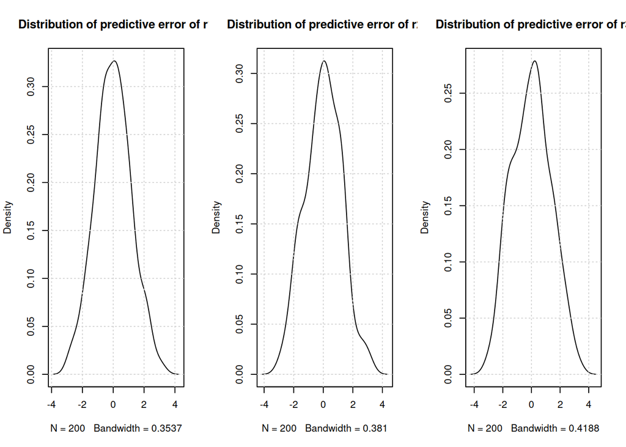

```r
par(mfrow=c(1,3))
plot(summary(predicpls),indicator="r1")
plot(summary(predicpls),indicator="r2")
plot(summary(predicpls),indicator="r3")
```

lorsque les distributions des erreurs sont symétrique par rapport a ZERO on n’utilise le RMSE et dans le cas contraire on n’utilise le MAE. Lorsque les valeurs du *PLS out-of-sample metrics* sont inferieur aux valeurs de *LM out-sample metrics* nous dirons alors que le *model a une valeur de prediction excellant* et *moyen* lorsque une var observable ne respecte condition enoncé prédament et si aucune la valeur observable ne respecte la condition nous concluons alors que le model n’a aucune valeur de prediction

[output not shown]

**passons aux modeles alternatifs** ici on cherche a avoir un R**2 meilleur avec le moin de lien possible

```r
ms2=relationships(
  paths("Quality","Value"),
  paths("Value","Csat"),
  paths("Csat","Repeat"),
  paths("Cost",c("Value","Repeat"))
)
```

modele2

```r
modelPLS2=estimate_pls(data,mm,ms2)
```

```
## Generating the seminr model
```

```
## All 200 observations are valid.
```

```r
modelPLS2=estimate_pls(data, mm, ms2)
```

```
## Generating the seminr model
## All 200 observations are valid.
```

```r
summary(modelPLS2)
```

```
##
## Results from  package seminr (2.3.2)
##
## Path Coefficients:
##          Value  Csat Repeat
## R^2      0.174 0.105  0.212
## AdjR^2   0.166 0.100  0.204
## Quality  0.298     .      .
## Value        . 0.324      .
## Csat         .     .  0.289
## Cost    -0.268     . -0.317
##
## Reliability:
##         alpha  rhoC   AVE  rhoA
## Quality 0.685 0.826 0.612 0.690
## Value   0.773 0.868 0.686 0.779
## Csat    0.725 0.844 0.644 0.729
## Cost    0.737 0.851 0.655 0.744
## Repeat  0.695 0.827 0.614 0.720
##
## Alpha, rhoC, and rhoA should exceed 0.7 while AVE should exceed 0.5
```

```r
plot(modelPLS2)
```

[interactive chart not shown]

comparons les avec leur BIC même interpretation que l’AIC connus depuis il faut inspecter it_criteria a l’exeption prêt qu’il pénalise les modele qui ont plus de relation

```r
sum1=summary(modelPLS)
sum2=summary(modelPLS2)
sum1$it_criteria
```

```
##       Value  Repeat    Csat
## AIC -33.120 -42.629 -42.150
## BIC -23.225 -32.734 -32.255
```

```r
sum2$it_criteria
```

```
##       Value    Csat  Repeat
## AIC -33.245 -19.165 -42.719
## BIC -23.350 -12.568 -32.824
```

BIC1 -32.734 BIC2 -32.824

le modele 2 est plus interessant que le modele 1 (très très marginale) que se soit pour l’AIC ou pou le BIC

une autre methide d’affichage

```r
it_criteria=c(sum1$it_criteria["BIC","Repeat"],
sum2$it_criteria["BIC","Repeat"])
names(it_criteria)=c("modele 1","modele 2")
it_criteria
```

```
##  modele 1  modele 2
## -32.73364 -32.82434
```

NTB: il est a noter que les suppressions des liens obeit a une certaine logique de vie même si le BIC nous fait comprendre qu’il ya amelioration du model